# Risk Factor Analysis

## Outcome Variable

**Outcome Variable:** pers_wasted624

## Predictor Variables

**Intervention Variable:** ever_co06

**Adjustment Set:**

- sex
- arm
- enstunt
- month
- brthmon
- vagbrth
- single
- W_gagebrth
- W_birthwt
- W_birthlen
- W_mage
- W_mhtcm
- W_meducyrs
- W_feducyrs
- W_parity
- delta_month
- delta_brthmon
- delta_vagbrth
- delta_single
- delta_W_gagebrth
- delta_W_birthwt
- delta_W_birthlen
- delta_W_mage
- delta_W_mhtcm
- delta_W_meducyrs
- delta_W_feducyrs
- delta_W_parity

## Stratifying Variables

The analysis was stratified on these variable(s):

- studyid
- country

## Data Summary

| studyid | country | ever_co06 | pers_wasted624 | n_cell | n |
| --- | --- | --- | --- | --- | --- |
| ki0047075b-MAL-ED | BANGLADESH | 0 | 0 | 215 | 240 |
| ki0047075b-MAL-ED | BANGLADESH | 0 | 1 | 16 | 240 |
| ki0047075b-MAL-ED | BANGLADESH | 1 | 0 | 7 | 240 |
| ki0047075b-MAL-ED | BANGLADESH | 1 | 1 | 2 | 240 |
| ki0047075b-MAL-ED | BRAZIL | 0 | 0 | 205 | 207 |
| ki0047075b-MAL-ED | BRAZIL | 0 | 1 | 2 | 207 |
| ki0047075b-MAL-ED | BRAZIL | 1 | 0 | 0 | 207 |
| ki0047075b-MAL-ED | BRAZIL | 1 | 1 | 0 | 207 |
| ki0047075b-MAL-ED | INDIA | 0 | 0 | 197 | 235 |
| ki0047075b-MAL-ED | INDIA | 0 | 1 | 21 | 235 |
| ki0047075b-MAL-ED | INDIA | 1 | 0 | 10 | 235 |
| ki0047075b-MAL-ED | INDIA | 1 | 1 | 7 | 235 |
| ki0047075b-MAL-ED | NEPAL | 0 | 0 | 227 | 235 |
| ki0047075b-MAL-ED | NEPAL | 0 | 1 | 1 | 235 |
| ki0047075b-MAL-ED | NEPAL | 1 | 0 | 6 | 235 |
| ki0047075b-MAL-ED | NEPAL | 1 | 1 | 1 | 235 |
| ki0047075b-MAL-ED | PERU | 0 | 0 | 267 | 270 |
| ki0047075b-MAL-ED | PERU | 0 | 1 | 2 | 270 |
| ki0047075b-MAL-ED | PERU | 1 | 0 | 1 | 270 |
| ki0047075b-MAL-ED | PERU | 1 | 1 | 0 | 270 |
| ki0047075b-MAL-ED | SOUTH AFRICA | 0 | 0 | 252 | 259 |
| ki0047075b-MAL-ED | SOUTH AFRICA | 0 | 1 | 2 | 259 |
| ki0047075b-MAL-ED | SOUTH AFRICA | 1 | 0 | 5 | 259 |
| ki0047075b-MAL-ED | SOUTH AFRICA | 1 | 1 | 0 | 259 |
| ki0047075b-MAL-ED | TANZANIA, UNITED REPUBLIC OF | 0 | 0 | 241 | 245 |
| ki0047075b-MAL-ED | TANZANIA, UNITED REPUBLIC OF | 0 | 1 | 0 | 245 |
| ki0047075b-MAL-ED | TANZANIA, UNITED REPUBLIC OF | 1 | 0 | 4 | 245 |
| ki0047075b-MAL-ED | TANZANIA, UNITED REPUBLIC OF | 1 | 1 | 0 | 245 |
| ki1000108-CMC-V-BCS-2002 | INDIA | 0 | 0 | 317 | 370 |
| ki1000108-CMC-V-BCS-2002 | INDIA | 0 | 1 | 22 | 370 |

[output cut: 102 more lines]

The following strata were considered:

- studyid: ki0047075b-MAL-ED, country: BANGLADESH
- studyid: ki0047075b-MAL-ED, country: BRAZIL
- studyid: ki0047075b-MAL-ED, country: INDIA
- studyid: ki0047075b-MAL-ED, country: NEPAL
- studyid: ki0047075b-MAL-ED, country: PERU
- studyid: ki0047075b-MAL-ED, country: SOUTH AFRICA
- studyid: ki0047075b-MAL-ED, country: TANZANIA, UNITED REPUBLIC OF
- studyid: ki1000108-CMC-V-BCS-2002, country: INDIA
- studyid: ki1000108-IRC, country: INDIA
- studyid: ki1000109-EE, country: PAKISTAN
- studyid: ki1000109-ResPak, country: PAKISTAN
- studyid: ki1000304b-SAS-CompFeed, country: INDIA
- studyid: ki1000304b-SAS-FoodSuppl, country: INDIA
- studyid: ki1017093-NIH-Birth, country: BANGLADESH
- studyid: ki1017093b-PROVIDE, country: BANGLADESH
- studyid: ki1017093c-NIH-Crypto, country: BANGLADESH
- studyid: ki1066203-TanzaniaChild2, country: TANZANIA, UNITED REPUBLIC OF
- studyid: ki1101329-Keneba, country: GAMBIA
- studyid: ki1112895-Guatemala BSC, country: GUATEMALA
- studyid: ki1113344-GMS-Nepal, country: NEPAL
- studyid: ki1114097-CMIN, country: BANGLADESH
- studyid: ki1114097-CMIN, country: BRAZIL
- studyid: ki1114097-CMIN, country: GUINEA-BISSAU
- studyid: ki1114097-CMIN, country: PERU
- studyid: ki1114097-CONTENT, country: PERU
- studyid: ki1119695-PROBIT, country: BELARUS
- studyid: ki1126311-ZVITAMBO, country: ZIMBABWE
- studyid: ki1135781-COHORTS, country: GUATEMALA
- studyid: ki1135781-COHORTS, country: INDIA
- studyid: ki1135781-COHORTS, country: PHILIPPINES
- studyid: ki1148112-LCNI-5, country: MALAWI
- studyid: kiGH5241-JiVitA-3, country: BANGLADESH
- studyid: kiGH5241-JiVitA-4, country: BANGLADESH

### Dropped Strata

Some strata were dropped due to rare outcomes:

- studyid: ki0047075b-MAL-ED, country: BANGLADESH
- studyid: ki0047075b-MAL-ED, country: BRAZIL
- studyid: ki0047075b-MAL-ED, country: NEPAL
- studyid: ki0047075b-MAL-ED, country: PERU
- studyid: ki0047075b-MAL-ED, country: SOUTH AFRICA
- studyid: ki0047075b-MAL-ED, country: TANZANIA, UNITED REPUBLIC OF
- studyid: ki1112895-Guatemala BSC, country: GUATEMALA
- studyid: ki1114097-CMIN, country: BRAZIL
- studyid: ki1114097-CMIN, country: GUINEA-BISSAU
- studyid: ki1114097-CMIN, country: PERU
- studyid: ki1114097-CONTENT, country: PERU
- studyid: ki1119695-PROBIT, country: BELARUS
- studyid: ki1148112-LCNI-5, country: MALAWI

## Methods Detail

We’re interested in the causal parameters $E[Y_a]$ for all values of $a \in \mathcal{A}$. These parameters represent the mean outcome if, possibly contrary to fact, we intervened to set all units to have $A=a$. Under the randomization and positivity assumptions, these are identified by the statistical parameters $\psi_a=E_W[E_{Y|A,W}(Y|A=a,W)]$. In addition, we’re interested in the mean of $Y$, $E[Y]$ under no intervention (the observed mean). We will estimate these parameters by using SuperLearner to fit the relevant likelihood factors – $E_{Y|A,W}(Y|A=a,W)$ and $p(A=a|W)$, and then updating our likelihood fit using a joint TMLE.

For unadjusted analyses ($W=\{\}$), initial likelihoods were estimated using Lrnr_glm to estimate the simple $E(Y|A)$ and Lrnr_mean to estimate $p(A)$. For adjusted analyses, a small library containing Lrnr_glmnet, Lrnr_xgboost, and Lrnr_mean was used.

Having estimated these parameters, we will then use the delta method to estimate relative risks and attributable risks relative to a prespecified baseline level of $A$.

# Results Detail

## Results Plots

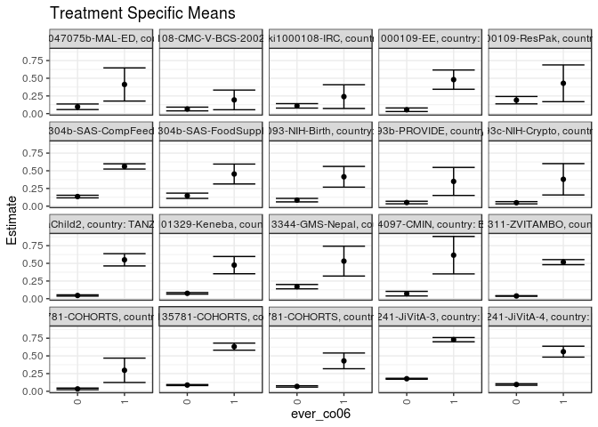

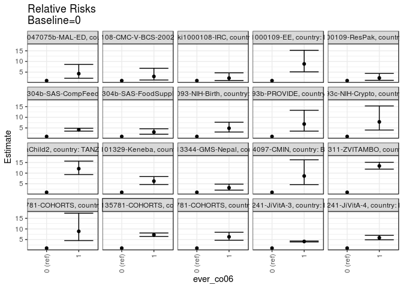

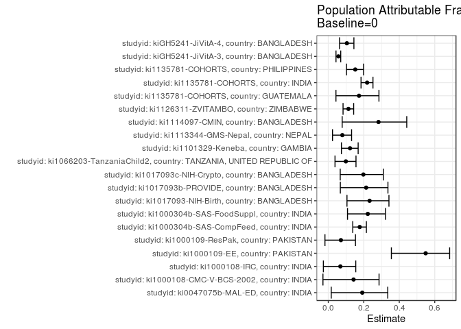

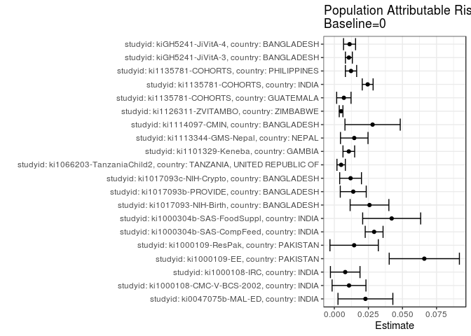

## Results Table

### Parameter: TSM

| studyid | country | intervention_level | baseline_level | estimate | ci_lower | ci_upper |
| --- | --- | --- | --- | --- | --- | --- |
| ki0047075b-MAL-ED | INDIA | 0 | NA | 0.0963303 | 0.0570810 | 0.1355796 |
| ki0047075b-MAL-ED | INDIA | 1 | NA | 0.4117647 | 0.1773150 | 0.6462144 |
| ki1000108-CMC-V-BCS-2002 | INDIA | 0 | NA | 0.0648968 | 0.0386378 | 0.0911557 |
| ki1000108-CMC-V-BCS-2002 | INDIA | 1 | NA | 0.1935484 | 0.0542844 | 0.3328124 |
| ki1000108-IRC | INDIA | 0 | NA | 0.1093750 | 0.0781199 | 0.1406301 |
| ki1000108-IRC | INDIA | 1 | NA | 0.2400000 | 0.0723815 | 0.4076185 |
| ki1000109-EE | PAKISTAN | 0 | NA | 0.0542948 | 0.0292217 | 0.0793680 |
| ki1000109-EE | PAKISTAN | 1 | NA | 0.4803295 | 0.3442318 | 0.6164271 |
| ki1000109-ResPak | PAKISTAN | 0 | NA | 0.1898148 | 0.1374036 | 0.2422261 |
| ki1000109-ResPak | PAKISTAN | 1 | NA | 0.4285714 | 0.1687812 | 0.6883617 |
| ki1000304b-SAS-CompFeed | INDIA | 0 | NA | 0.1356569 | 0.1171332 | 0.1541807 |
| ki1000304b-SAS-CompFeed | INDIA | 1 | NA | 0.5616124 | 0.5244612 | 0.5987636 |
| ki1000304b-SAS-FoodSuppl | INDIA | 0 | NA | 0.1469700 | 0.1097801 | 0.1841599 |
| ki1000304b-SAS-FoodSuppl | INDIA | 1 | NA | 0.4543625 | 0.3135884 | 0.5951366 |
| ki1017093-NIH-Birth | BANGLADESH | 0 | NA | 0.0851001 | 0.0604986 | 0.1097016 |
| ki1017093-NIH-Birth | BANGLADESH | 1 | NA | 0.4152315 | 0.2685955 | 0.5618675 |
| ki1017093b-PROVIDE | BANGLADESH | 0 | NA | 0.0511609 | 0.0333083 | 0.0690136 |
| ki1017093b-PROVIDE | BANGLADESH | 1 | NA | 0.3496989 | 0.1516786 | 0.5477192 |
| ki1017093c-NIH-Crypto | BANGLADESH | 0 | NA | 0.0483552 | 0.0325632 | 0.0641471 |
| ki1017093c-NIH-Crypto | BANGLADESH | 1 | NA | 0.3798071 | 0.1583575 | 0.6012566 |
| ki1066203-TanzaniaChild2 | TANZANIA, UNITED REPUBLIC OF | 0 | NA | 0.0455455 | 0.0362596 | 0.0548315 |
| ki1066203-TanzaniaChild2 | TANZANIA, UNITED REPUBLIC OF | 1 | NA | 0.5500000 | 0.4635436 | 0.6364564 |
| ki1101329-Keneba | GAMBIA | 0 | NA | 0.0761598 | 0.0650773 | 0.0872423 |
| ki1101329-Keneba | GAMBIA | 1 | NA | 0.4747377 | 0.3527680 | 0.5967074 |
| ki1113344-GMS-Nepal | NEPAL | 0 | NA | 0.1701281 | 0.1391168 | 0.2011394 |
| ki1113344-GMS-Nepal | NEPAL | 1 | NA | 0.5312387 | 0.3202272 | 0.7422502 |
| ki1114097-CMIN | BANGLADESH | 0 | NA | 0.0711297 | 0.0384773 | 0.1037821 |
| ki1114097-CMIN | BANGLADESH | 1 | NA | 0.6153846 | 0.3503965 | 0.8803728 |
| ki1126311-ZVITAMBO | ZIMBABWE | 0 | NA | 0.0386732 | 0.0349165 | 0.0424300 |
| ki1126311-ZVITAMBO | ZIMBABWE | 1 | NA | 0.5170056 | 0.4809610 | 0.5530503 |
| ki1135781-COHORTS | GUATEMALA | 0 | NA | 0.0333670 | 0.0221687 | 0.0445654 |
| ki1135781-COHORTS | GUATEMALA | 1 | NA | 0.2962963 | 0.1239753 | 0.4686172 |
| ki1135781-COHORTS | INDIA | 0 | NA | 0.0873193 | 0.0801651 | 0.0944734 |
| ki1135781-COHORTS | INDIA | 1 | NA | 0.6310992 | 0.5811548 | 0.6810437 |
| ki1135781-COHORTS | PHILIPPINES | 0 | NA | 0.0682471 | 0.0587917 | 0.0777025 |
| ki1135781-COHORTS | PHILIPPINES | 1 | NA | 0.4294494 | 0.3183826 | 0.5405161 |
| kiGH5241-JiVitA-3 | BANGLADESH | 0 | NA | 0.1771293 | 0.1705497 | 0.1837089 |
| kiGH5241-JiVitA-3 | BANGLADESH | 1 | NA | 0.7296591 | 0.6997540 | 0.7595641 |
| kiGH5241-JiVitA-4 | BANGLADESH | 0 | NA | 0.0954355 | 0.0849327 | 0.1059384 |
| kiGH5241-JiVitA-4 | BANGLADESH | 1 | NA | 0.5598182 | 0.4828998 | 0.6367367 |

### Parameter: E(Y)

| studyid | country | intervention_level | baseline_level | estimate | ci_lower | ci_upper |
| --- | --- | --- | --- | --- | --- | --- |
| ki0047075b-MAL-ED | INDIA | NA | NA | 0.1191489 | 0.0776405 | 0.1606574 |
| ki1000108-CMC-V-BCS-2002 | INDIA | NA | NA | 0.0756757 | 0.0486905 | 0.1026609 |
| ki1000108-IRC | INDIA | NA | NA | 0.1173594 | 0.0861296 | 0.1485892 |
| ki1000109-EE | PAKISTAN | NA | NA | 0.1203209 | 0.0873047 | 0.1533370 |
| ki1000109-ResPak | PAKISTAN | NA | NA | 0.2043478 | 0.1521230 | 0.2565727 |
| ki1000304b-SAS-CompFeed | INDIA | NA | NA | 0.1648590 | 0.1452632 | 0.1844548 |
| ki1000304b-SAS-FoodSuppl | INDIA | NA | NA | 0.1890547 | 0.1507312 | 0.2273783 |
| ki1017093-NIH-Birth | BANGLADESH | NA | NA | 0.1109057 | 0.0844206 | 0.1373909 |
| ki1017093b-PROVIDE | BANGLADESH | NA | NA | 0.0650407 | 0.0455353 | 0.0845460 |
| ki1017093c-NIH-Crypto | BANGLADESH | NA | NA | 0.0602740 | 0.0429977 | 0.0775502 |
| ki1066203-TanzaniaChild2 | TANZANIA, UNITED REPUBLIC OF | NA | NA | 0.0505451 | 0.0409848 | 0.0601054 |
| ki1101329-Keneba | GAMBIA | NA | NA | 0.0867841 | 0.0752007 | 0.0983676 |
| ki1113344-GMS-Nepal | NEPAL | NA | NA | 0.1847458 | 0.1534039 | 0.2160876 |
| ki1114097-CMIN | BANGLADESH | NA | NA | 0.0992063 | 0.0622241 | 0.1361886 |
| ki1126311-ZVITAMBO | ZIMBABWE | NA | NA | 0.0436299 | 0.0397432 | 0.0475165 |
| ki1135781-COHORTS | GUATEMALA | NA | NA | 0.0403543 | 0.0282479 | 0.0524607 |
| ki1135781-COHORTS | INDIA | NA | NA | 0.1117886 | 0.1043466 | 0.1192306 |
| ki1135781-COHORTS | PHILIPPINES | NA | NA | 0.0804843 | 0.0704205 | 0.0905481 |
| kiGH5241-JiVitA-3 | BANGLADESH | NA | NA | 0.1878008 | 0.1812627 | 0.1943389 |
| kiGH5241-JiVitA-4 | BANGLADESH | NA | NA | 0.1066106 | 0.0960765 | 0.1171447 |

### Parameter: RR

| studyid | country | intervention_level | baseline_level | estimate | ci_lower | ci_upper |
| --- | --- | --- | --- | --- | --- | --- |
| ki0047075b-MAL-ED | INDIA | 0 | 0 | 1.000000 | 1.000000 | 1.000000 |
| ki0047075b-MAL-ED | INDIA | 1 | 0 | 4.274510 | 2.122351 | 8.609053 |
| ki1000108-CMC-V-BCS-2002 | INDIA | 0 | 0 | 1.000000 | 1.000000 | 1.000000 |
| ki1000108-CMC-V-BCS-2002 | INDIA | 1 | 0 | 2.982405 | 1.306343 | 6.808882 |
| ki1000108-IRC | INDIA | 0 | 0 | 1.000000 | 1.000000 | 1.000000 |
| ki1000108-IRC | INDIA | 1 | 0 | 2.194286 | 1.031740 | 4.666768 |
| ki1000109-EE | PAKISTAN | 0 | 0 | 1.000000 | 1.000000 | 1.000000 |
| ki1000109-EE | PAKISTAN | 1 | 0 | 8.846686 | 5.140305 | 15.225529 |
| ki1000109-ResPak | PAKISTAN | 0 | 0 | 1.000000 | 1.000000 | 1.000000 |
| ki1000109-ResPak | PAKISTAN | 1 | 0 | 2.257840 | 1.159868 | 4.395189 |
| ki1000304b-SAS-CompFeed | INDIA | 0 | 0 | 1.000000 | 1.000000 | 1.000000 |
| ki1000304b-SAS-CompFeed | INDIA | 1 | 0 | 4.139946 | 3.517209 | 4.872942 |
| ki1000304b-SAS-FoodSuppl | INDIA | 0 | 0 | 1.000000 | 1.000000 | 1.000000 |
| ki1000304b-SAS-FoodSuppl | INDIA | 1 | 0 | 3.091533 | 2.071122 | 4.614684 |
| ki1017093-NIH-Birth | BANGLADESH | 0 | 0 | 1.000000 | 1.000000 | 1.000000 |
| ki1017093-NIH-Birth | BANGLADESH | 1 | 0 | 4.879330 | 3.088649 | 7.708180 |
| ki1017093b-PROVIDE | BANGLADESH | 0 | 0 | 1.000000 | 1.000000 | 1.000000 |
| ki1017093b-PROVIDE | BANGLADESH | 1 | 0 | 6.835271 | 3.514975 | 13.291965 |
| ki1017093c-NIH-Crypto | BANGLADESH | 0 | 0 | 1.000000 | 1.000000 | 1.000000 |
| ki1017093c-NIH-Crypto | BANGLADESH | 1 | 0 | 7.854530 | 4.026937 | 15.320242 |
| ki1066203-TanzaniaChild2 | TANZANIA, UNITED REPUBLIC OF | 0 | 0 | 1.000000 | 1.000000 | 1.000000 |
| ki1066203-TanzaniaChild2 | TANZANIA, UNITED REPUBLIC OF | 1 | 0 | 12.075824 | 9.334896 | 15.621547 |
| ki1101329-Keneba | GAMBIA | 0 | 0 | 1.000000 | 1.000000 | 1.000000 |
| ki1101329-Keneba | GAMBIA | 1 | 0 | 6.233445 | 4.640225 | 8.373697 |
| ki1113344-GMS-Nepal | NEPAL | 0 | 0 | 1.000000 | 1.000000 | 1.000000 |
| ki1113344-GMS-Nepal | NEPAL | 1 | 0 | 3.122581 | 2.017257 | 4.833548 |
| ki1114097-CMIN | BANGLADESH | 0 | 0 | 1.000000 | 1.000000 | 1.000000 |
| ki1114097-CMIN | BANGLADESH | 1 | 0 | 8.651584 | 4.610498 | 16.234669 |
| ki1126311-ZVITAMBO | ZIMBABWE | 0 | 0 | 1.000000 | 1.000000 | 1.000000 |
| ki1126311-ZVITAMBO | ZIMBABWE | 1 | 0 | 13.368562 | 11.861991 | 15.066480 |
| ki1135781-COHORTS | GUATEMALA | 0 | 0 | 1.000000 | 1.000000 | 1.000000 |
| ki1135781-COHORTS | GUATEMALA | 1 | 0 | 8.879910 | 4.537246 | 17.379001 |
| ki1135781-COHORTS | INDIA | 0 | 0 | 1.000000 | 1.000000 | 1.000000 |
| ki1135781-COHORTS | INDIA | 1 | 0 | 7.227490 | 6.451023 | 8.097416 |
| ki1135781-COHORTS | PHILIPPINES | 0 | 0 | 1.000000 | 1.000000 | 1.000000 |
| ki1135781-COHORTS | PHILIPPINES | 1 | 0 | 6.292566 | 4.692590 | 8.438067 |
| kiGH5241-JiVitA-3 | BANGLADESH | 0 | 0 | 1.000000 | 1.000000 | 1.000000 |
| kiGH5241-JiVitA-3 | BANGLADESH | 1 | 0 | 4.119359 | 3.892345 | 4.359613 |
| kiGH5241-JiVitA-4 | BANGLADESH | 0 | 0 | 1.000000 | 1.000000 | 1.000000 |
| kiGH5241-JiVitA-4 | BANGLADESH | 1 | 0 | 5.865931 | 4.915535 | 7.000082 |

### Parameter: PAR

| studyid | country | intervention_level | baseline_level | estimate | ci_lower | ci_upper |
| --- | --- | --- | --- | --- | --- | --- |
| ki0047075b-MAL-ED | INDIA | 0 | NA | 0.0228187 | 0.0026860 | 0.0429513 |
| ki1000108-CMC-V-BCS-2002 | INDIA | 0 | NA | 0.0107789 | -0.0016393 | 0.0231971 |
| ki1000108-IRC | INDIA | 0 | NA | 0.0079844 | -0.0028711 | 0.0188399 |
| ki1000109-EE | PAKISTAN | 0 | NA | 0.0660260 | 0.0402656 | 0.0917864 |
| ki1000109-ResPak | PAKISTAN | 0 | NA | 0.0145330 | -0.0032125 | 0.0322785 |
| ki1000304b-SAS-CompFeed | INDIA | 0 | NA | 0.0292021 | 0.0226599 | 0.0357443 |
| ki1000304b-SAS-FoodSuppl | INDIA | 0 | NA | 0.0420848 | 0.0207934 | 0.0633761 |
| ki1017093-NIH-Birth | BANGLADESH | 0 | NA | 0.0258056 | 0.0115887 | 0.0400226 |
| ki1017093b-PROVIDE | BANGLADESH | 0 | NA | 0.0138797 | 0.0043577 | 0.0234017 |
| ki1017093c-NIH-Crypto | BANGLADESH | 0 | NA | 0.0119188 | 0.0039350 | 0.0199026 |
| ki1066203-TanzaniaChild2 | TANZANIA, UNITED REPUBLIC OF | 0 | NA | 0.0049995 | 0.0019204 | 0.0080787 |
| ki1101329-Keneba | GAMBIA | 0 | NA | 0.0106244 | 0.0063396 | 0.0149091 |
| ki1113344-GMS-Nepal | NEPAL | 0 | NA | 0.0146177 | 0.0045184 | 0.0247169 |
| ki1114097-CMIN | BANGLADESH | 0 | NA | 0.0280766 | 0.0077909 | 0.0483623 |
| ki1126311-ZVITAMBO | ZIMBABWE | 0 | NA | 0.0049566 | 0.0036034 | 0.0063098 |
| ki1135781-COHORTS | GUATEMALA | 0 | NA | 0.0069873 | 0.0017121 | 0.0122625 |
| ki1135781-COHORTS | INDIA | 0 | NA | 0.0244693 | 0.0204846 | 0.0284541 |
| ki1135781-COHORTS | PHILIPPINES | 0 | NA | 0.0122372 | 0.0080988 | 0.0163757 |
| kiGH5241-JiVitA-3 | BANGLADESH | 0 | NA | 0.0106715 | 0.0081279 | 0.0132151 |
| kiGH5241-JiVitA-4 | BANGLADESH | 0 | NA | 0.0111751 | 0.0067618 | 0.0155884 |

### Parameter: PAF

| studyid | country | intervention_level | baseline_level | estimate | ci_lower | ci_upper |
| --- | --- | --- | --- | --- | --- | --- |
| ki0047075b-MAL-ED | INDIA | 0 | NA | 0.1915138 | 0.0165980 | 0.3353176 |
| ki1000108-CMC-V-BCS-2002 | INDIA | 0 | NA | 0.1424357 | -0.0300892 | 0.2860653 |
| ki1000108-IRC | INDIA | 0 | NA | 0.0680339 | -0.0277289 | 0.1548735 |
| ki1000109-EE | PAKISTAN | 0 | NA | 0.5487495 | 0.3555180 | 0.6840454 |
| ki1000109-ResPak | PAKISTAN | 0 | NA | 0.0711190 | -0.0188116 | 0.1531114 |
| ki1000304b-SAS-CompFeed | INDIA | 0 | NA | 0.1771336 | 0.1378474 | 0.2146295 |
| ki1000304b-SAS-FoodSuppl | INDIA | 0 | NA | 0.2226062 | 0.1083548 | 0.3222179 |
| ki1017093-NIH-Birth | BANGLADESH | 0 | NA | 0.2326807 | 0.1053604 | 0.3418814 |
| ki1017093b-PROVIDE | BANGLADESH | 0 | NA | 0.2134005 | 0.0678218 | 0.3362442 |
| ki1017093c-NIH-Crypto | BANGLADESH | 0 | NA | 0.1977440 | 0.0672602 | 0.3099740 |
| ki1066203-TanzaniaChild2 | TANZANIA, UNITED REPUBLIC OF | 0 | NA | 0.0989126 | 0.0378212 | 0.1561252 |
| ki1101329-Keneba | GAMBIA | 0 | NA | 0.1224230 | 0.0739999 | 0.1683140 |
| ki1113344-GMS-Nepal | NEPAL | 0 | NA | 0.0791231 | 0.0238208 | 0.1312925 |
| ki1114097-CMIN | BANGLADESH | 0 | NA | 0.2830126 | 0.0782623 | 0.4422806 |
| ki1126311-ZVITAMBO | ZIMBABWE | 0 | NA | 0.1136060 | 0.0831648 | 0.1430364 |
| ki1135781-COHORTS | GUATEMALA | 0 | NA | 0.1731485 | 0.0431505 | 0.2854850 |
| ki1135781-COHORTS | INDIA | 0 | NA | 0.2188894 | 0.1845210 | 0.2518093 |
| ki1135781-COHORTS | PHILIPPINES | 0 | NA | 0.1520449 | 0.1024334 | 0.1989142 |
| kiGH5241-JiVitA-3 | BANGLADESH | 0 | NA | 0.0568235 | 0.0433943 | 0.0700641 |
| kiGH5241-JiVitA-4 | BANGLADESH | 0 | NA | 0.1048216 | 0.0634558 | 0.1443604 |